DS 6030 | Spring 2026 | University of Virginia

# Homework #0: Hello DS-6030

Author

Faizan Khan (xdy6sg)

Published

January 21, 2026

# Getting Help

The purpose of this (ungraded) homework is to help get you prepared for the semester. Don’t panic if you don’t immediately know the answers to some of these. I expect everyone will need to look things up. Take note of the areas that are rusty and plan to spend a bit of extra time to get up to speed. If some of these items are not even remotely familiar to you, then you probably have not satisfied the pre-requisite material; review the course syllabus and speak to me about any questions.

The teaching staff (TA and myself) are here to help! Don’t wait too long before asking for help and do let us know right away if you are starting to fall behind. I will also publish the solutions after due date. It is **highly encouraged** that you study the posted solutions.

# Course Tools

## a. Working with Quarto

1. Install or update quarto https://quarto.org/docs/get-started/ to version 1.8.26 (or greater).
   - If you are using VSCode, install the [Quarto extension](https://marketplace.visualstudio.com/items?itemName=quarto.quarto%3E).
2. Course Homework Style

In order to help with grading, you need to use special formatting to generate the homework html file.

Download the following files and put them in the top level of where you will keep your homework.

- _quarto.yml
- hw-style.css

An example directory structure is:

```
hw/
├─ _quarto.yml
├─ hw-style.css
├─ hw0.qmd
├─ hw0.html
├─ hw1.qmd
├─ hw1.html
...
```

## b. Update IDE

Update your IDE and (optionally) try a new one! These will all work great for this course.

- [Positron](https://positron.posit.co/) (2026.01.0-147)
- [RStudio](https://posit.co/download/rstudio-desktop/) (2026.01.0+392)
- [VSCode](https://code.visualstudio.com/) (1.108)
  - If using VSCode, install the [Quarto extension](https://marketplace.visualstudio.com/items?itemName=quarto.quarto%3E)

## c. Update R

- Use the latest version (R 4.5.2, Quarto 1.8.26).
  - Installation help R: https://cran.rstudio.com/
- Install/Update the following packages we will meet during this course:
  - Using R and Python: `reticulate`
  - Dynamic report generation: `rmarkdown`, `knitr`, `quarto`
  - Utility: `remotes`
  - Working with Data: `tidyverse`
  - Data: `ISLR`, `moderndive`, `MASS`
  - Resampling: `boot`, `rsample`
  - Modeling: `tidymodels`
  - Regression: `glmnet`, `FNN`,
  - Classification: `e1071`,
  - Trees: `rpart`, `rpart.plot`, `randomForest`, `ranger`
  - Ensembles: `xgboost`, `lightgbm`, `bonsai`
  - Forecasting: `fpp3`

To install/update an R package, open an R console and run

```r
# Example set of packages (most important for now)
install.packages("reticulate")
install.packages("rmarkdown")
install.packages("knitr")
install.packages("quarto")
install.packages("tidymodels")
install.packages("tidyverse")
# ... add any more you want. You can always add more anytime.
```

You can see which of your existing packages need updating by running:

```r
old.packages() %>% as_tibble()
```

Or use the `update.packages()` function to update them.

Note: Do not call `install.packages()` in this Quarto document; it only needs to be done once from the console. However you will need to use `library()` in Quarto since it needs to be called every time the document is compiled.

Below are some resources for help with modern R.

**TipR Resources**

### Tidyverse Resources

Read the following sections in [R for Data Science 2e](https://r4ds.hadley.nz/):

- The Whole Game
  - Chapters 2-9
- Visualize
  - Chapters 10-12
- Transform
  - 12-15, 19
- Program
  - 26-27
- Communicate
  - 29

### Cheatsheets and resources

[Posit Cheatsheets](https://posit.co/resources/cheatsheets/)

### **RStudio and Quarto**

- [RStudio IDE Cheatsheet](https://rstudio.github.io/cheatsheets/html/rstudio-ide.html)
- [Quarto Website](https://quarto.org/docs/authoring/markdown-basics.html)
- [Quarto Cheatsheet](https://rstudio.github.io/cheatsheets/html/quarto.html)
- [Latex Cheatsheet](https://wch.github.io/latexsheet/latexsheet-0.png)

### **R**

- [Base R](https://rstudio.github.io/cheatsheets/base-r.pdf)
- [Data Visualization Cheatsheet](https://rstudio.github.io/cheatsheets/html/data-visualization.html)
  - [`ggplot2` website](https://ggplot2.tidyverse.org/)
- [Tidy Data Cheatsheet](https://rstudio.github.io/cheatsheets/html/tidyr.html)
  - [`tidyr` website](https://tidyr.tidyverse.org/)
- [Data Transform Cheatsheet](https://rstudio.github.io/cheatsheets/html/data-transformation.html)
  - [`dplyr` website](https://dplyr.tidyverse.org/)
- [Factors with forcats Cheatsheet](https://rstudio.github.io/cheatsheets/html/factors.html)
  - [`forcats` website](https://forcats.tidyverse.org/)
- [Data Import Cheatsheet](https://rstudio.github.io/cheatsheets/html/data-import.html)
  - [`readr` website](https://readr.tidyverse.org/)
- [Apply Functions Cheatsheet](https://rstudio.github.io/cheatsheets/html/purrr.html)
  - [`purrr` website](https://purrr.tidyverse.org/)

### **Python with RStudio/RMarkdown** (Optional)

- [Python with R and Reticulate Cheatsheet](https://rstudio.github.io/cheatsheets/html/reticulate.html)

## d. Python Package Manager

I recommend [uv](https://docs.astral.sh/uv/) for python package management.

- To get you started, add the following `pyproject.toml` file to your top-level class directory (e.g., `DS6030/`):

```
pyproject.toml
```

```
[project]
name = "DS6030"
version = "0.1.0"
requires-python = ">=3.14"

dependencies = [
  # numerical computing
  "numpy",
  "scipy",

  # data manipulation
  "pandas",
  "polars",
  "ibis-framework",

  # machine learning
  "scikit-learn",
  "statsmodels",

  # plotting and visualization
  "matplotlib",
  "seaborn",
  "plotnine",

  # notebooks and execution
  "jupyterlab",
  "ipykernel"
]
```

- Then run the following to add the python and packages from the pyproject.toml:

```
uv sync
```

# Problem 1: Math Notation

## a. Least Squares

What are the equations for the least squares coefficients in linear regression (in matrix notation)? Use $X$ for the model/design/predictor matrix, and $Y$ the vector of outcomes.

**NoteSolution**

The least squares coefficients in matrix notation are:

$$\hat{\beta} = (X^T X)^{-1} X^T Y$$

Where:

- $X$ is the $n \times p$ design/predictor matrix (with $n$ observations and $p$ predictors)
- $Y$ is the $n \times 1$ vector of outcomes
- $X^T$ is the transpose of $X$
- $(X^T X)^{-1}$ is the inverse of the matrix $X^T X$

This is derived by minimizing the sum of squared residuals $||Y - X\beta||^2$ with respect to $\beta$, taking the derivative, setting it equal to zero, and solving for $\beta$.

**Derivation:**

1. We want to minimize the residual sum of squares: $RSS = (Y - X\beta)^T(Y - X\beta)$
2. Take the derivative with respect to $\beta$:
   $$\frac{\partial RSS}{\partial \beta} = -2X^T Y + 2X^T X \beta$$
3. Set equal to zero:
   $$X^T X \beta = X^T Y$$
4. Solve for $\beta$:
   $$\hat{\beta} = (X^T X)^{-1} X^T Y$$

## b. MLE

Let $x_1, x_2, \ldots, x_n$ be a sample of length of time that a customer is on the phone with a call center help line. We feel comfortable modeling the data as coming from an *exponential distribution*. What is the MLE (Maximum Likelihood Estimate) of the parameter? Show your steps.

**NoteSolution**

The exponential distribution has PDF: $f(x; \lambda) = \lambda e^{-\lambda x}$ for $x \geq 0$, where $\lambda > 0$ is the rate parameter.

**Step 1: Write the likelihood function**

$$L(\lambda) = \prod_{i=1}^{n} f(x_i; \lambda) = \prod_{i=1}^{n} \lambda e^{-\lambda x_i} = \lambda^n e^{-\lambda \sum_{i=1}^{n} x_i}$$

**Step 2: Take the log-likelihood**

$$\ell(\lambda) = \ln L(\lambda) = n \ln(\lambda) - \lambda \sum_{i=1}^{n} x_i$$

**Step 3: Take the derivative with respect to $\lambda$**

$$\frac{d\ell}{d\lambda} = \frac{n}{\lambda} - \sum_{i=1}^{n} x_i$$

**Step 4: Set equal to zero and solve**

$$\frac{n}{\hat{\lambda}} - \sum_{i=1}^{n} x_i = 0$$

$$\frac{n}{\hat{\lambda}} = \sum_{i=1}^{n} x_i$$

$$\hat{\lambda}_{MLE} = \frac{n}{\sum_{i=1}^{n} x_i} = \frac{1}{\bar{x}}$$

**Conclusion:** The MLE of the rate parameter is $\hat{\lambda} = \frac{1}{\bar{x}}$, the reciprocal of the sample mean.

(Equivalently, if using the mean parameterization where $\theta = 1/\lambda$, then $\hat{\theta}_{MLE} = \bar{x}$, the sample mean.)

# Problem 2: Coding Practice

## a. Simulation

Simulate 100 observations from the following model:

- $X \sim N(\mu = 1, \sigma = 1)$
- $Y \sim N(\mu = 1 + 2X, \sigma = 2)$
- $Z = \begin{cases} 1 &\quad Y<0 \\ 2 &\quad Y \ge 0 \end{cases}$

**NoteSolution**

```r
set.seed(2026)  # for reproducibility

# Simulate 100 observations
n <- 100

# X ~ N(mu = 1, sigma = 1)
X <- rnorm(n, mean = 1, sd = 1)

# Y ~ N(mu = 1 + 2X, sigma = 2)
Y <- rnorm(n, mean = 1 + 2*X, sd = 2)

# Z = 1 if Y < 0, Z = 2 if Y >= 0
Z <- ifelse(Y < 0, 1, 2)

# Combine into a data frame
sim_data <- data.frame(X = X, Y = Y, Z = Z)

# Preview the data
head(sim_data)
```

```
        X      Y Z
1  1.5206  6.474 2
2 -0.0797 -0.147 1
3  1.1392  2.823 2
4  0.9153  0.607 2
5  0.3334  3.658 2
6 -1.5161 -0.909 1
```

## b. Scatterplot

Make a scatter plot of the data. Put $X$ on the x-axis and $Y$ on the y-axis. Color the points according to $Z$.

**NoteSolution**

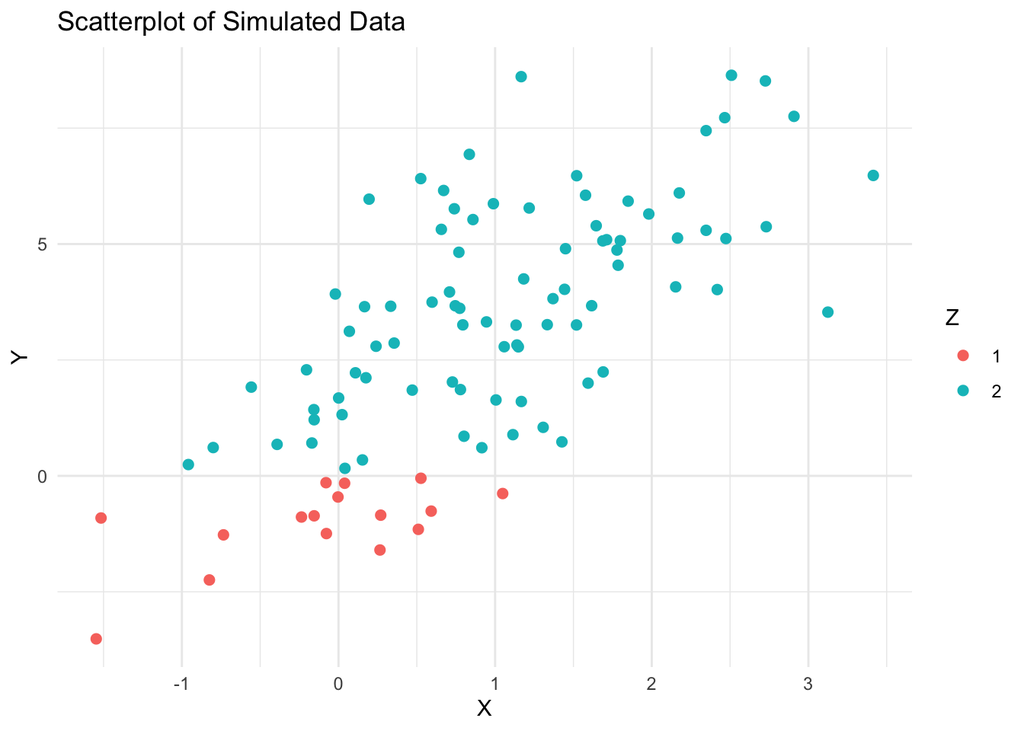

```r
library(ggplot2)

ggplot(sim_data, aes(x = X, y = Y, color = factor(Z))) +
  geom_point(size = 2) +
  labs(
    title = "Scatterplot of Simulated Data",
    x = "X",
    y = "Y",
    color = "Z"
  ) +
  theme_minimal()
```

## c. Function

Write a function that adds two numbers together and squares the result.

**NoteSolution**

```r
# Function that adds two numbers and squares the result
add_and_square <- function(a, b) {
  result <- (a + b)^2
  return(result)
}

# Test the function
add_and_square(2, 3)  # Should return (2+3)^2 = 25
```

```
[1] 25
```

```r
add_and_square(1, 4)  # Should return (1+4)^2 = 25
```

```
[1] 25
```

```r
add_and_square(-1, 5) # Should return (-1+5)^2 = 16
```

```
[1] 16
```

# Problem 3: Statistics

## a. Quantiles

Find two [quantiles](https://en.wikipedia.org/wiki/Quantile) that capture 95% of the following data:

**R**

```r
set.seed(2026)
x = runif(n=100, min=2, max=22)
```

**Python**

```python
import numpy as np

rng = np.random.default_rng(2026)
x = rng.uniform(low=2, high=22, size=100)
```

**NoteSolution**

```r
set.seed(2026)
x = runif(n=100, min=2, max=22)

# Find the 2.5th and 97.5th percentiles to capture 95% of the data
quantiles_95 <- quantile(x, probs = c(0.025, 0.975))
quantiles_95
```

```
 2.5% 97.5%
 2.22 21.21
```

The two quantiles that capture 95% of the data are the 2.5th percentile and the 97.5th percentile. This leaves 2.5% of data in each tail, with 95% of observations falling between these values.

## b. Confidence Interval

A new machine learning model, developed by UVA researchers, uses biopsy images to predict if a child has enteropathy or celiac disease. [In a study of 102 patients](https://jamanetwork.com/journals/jamanetworkopen/fullarticle/2735765), the model was able to correctly classify 95 of the images.

Find the 90% [confidence interval](https://en.wikipedia.org/wiki/Confidence_interval) for the probability a patient is correctly classified?

**NoteSolution**

```r
# Given data
n <- 102        # total patients
x <- 95         # correctly classified
p_hat <- x / n  # sample proportion

p_hat  # point estimate
```

```
[1] 0.931
```

```r
# Method 1: Using prop.test (Wilson score interval - recommended)
prop.test(x = 95, n = 102, conf.level = 0.90)
```

```
    1-sample proportions test with continuity correction

data:  95 out of 102, null probability 0.5
X-squared = 74, df = 1, p-value <2e-16
alternative hypothesis: true p is not equal to 0.5
90 percent confidence interval:
 0.872 0.966
sample estimates:
    p
0.931
```

```r
# Method 2: Manual calculation using normal approximation (Wald interval)
z <- qnorm(0.95)  # 90% CI uses z = 1.645 (leaving 5% in each tail)
se <- sqrt(p_hat * (1 - p_hat) / n)  # standard error

lower <- p_hat - z * se
upper <- p_hat + z * se

c(lower = lower, upper = upper)
```

```
lower upper
0.890 0.973
```

## c. Linear Models

- Albemarle County, VA real estate assessment data can be found [at this link](https://raw.githubusercontent.com/uvastatlab/phdplus/master/data/albemarle_homes.csv). Data collected by UVAs StatLab as part of the PhD plus program (https://github.com/uvastatlab/phdplus).
1. Fit a linear regression model that predicts the `totalvalue` using the predictors: `condition`, size (`finsqft`), and location (`city`).
2. What are the fitted model parameters (i.e., the estimated coefficients)?
3. What is the estimated `totalvalue` for home with the following characteristics?

| finsqft | city | condition |
| --- | --- | --- |
| 2500 | EARLYSVILLE | Good |
| 1850 | CROZET | Fair |

**NoteSolution**

```r
# Load the data
homes <- read.csv("https://raw.githubusercontent.com/uvastatlab/phdplus/master/data/albemarle_homes.csv")

# Preview the data
head(homes)
```

```
             tmp yearbuilt yearremodeled       usecode condition finsqft
1 006000000011B0      2006             0 Single Family   Average    1922
2 00600000003800      2003             0 Single Family   Average    1848
3 007000000018B0      1974             0 Single Family   Average    1368
4 007000000042A0      1954             0 Single Family   Average    1092
5 007000000042B0      1987             0 Single Family   Average    1344
6 00700000004600      1920          1987 Single Family      Fair    2131
         cooling fp_num bedroom fullbath halfbath totalrooms   city   zip
1    Central Air      1       3        3        0         10 CROZET 22932
2    Central Air      0       3        2        0          7 CROZET 22932
3 No Central Air      0       3        1        0          5  OTHER 22940
4 No Central Air      0       4        1        0          6  OTHER 22940
5    Central Air      0       3        2        0          5  OTHER 22940
6 No Central Air      0       5        2        0          8  OTHER 22940
  lotsize landvalue improvementsvalue totalvalue lastsaleprice
1    5.00    109800            300100     409900             0
2   61.19    444100             79000     523100             0
3    5.39    100400            128400     228800             0
4    5.80    100700             77200     177900             0
5    2.34     66500            165900     232400             0
6   35.10    340300             85000     425300             0
          lastsaledate age med_age fp landuse insub remodel
1 2009-08-05T00:00:00Z  10      17  1       0     0       0
2 1991-05-20T00:00:00Z  13      17  0       0     0       0
3 1989-02-23T00:00:00Z  42      33  0       0     0       0
4 2001-10-05T00:00:00Z  62      33  0       0     0       0
5 2009-05-20T00:00:00Z  29      33  0       0     0       0
6 2011-02-09T00:00:00Z  96      33  0       1     0       1
```

```r
# Fit the linear regression model
model <- lm(totalvalue ~ condition + finsqft + city, data = homes)

# View the model summary
summary(model)
```

```
Call:
lm(formula = totalvalue ~ condition + finsqft + city, data = homes)

Residuals:
     Min       1Q   Median       3Q      Max
-1065605   -83790   -18288    42699 11061827

Coefficients:
                      Estimate Std. Error t value Pr(>|t|)
(Intercept)          -1.43e+05   1.15e+04  -12.50  < 2e-16 ***
conditionExcellent    3.09e+04   5.64e+03    5.47  4.4e-08 ***
conditionFair         2.17e+04   8.54e+03    2.55  0.01091 *
conditionGood        -8.58e+03   3.13e+03   -2.74  0.00609 **
conditionNone        -8.50e+04   1.44e+04   -5.92  3.3e-09 ***
conditionPoor         1.75e+04   1.90e+04    0.92  0.35762
conditionSubstandard  1.07e+05   6.26e+04    1.71  0.08709 .
finsqft               2.74e+02   1.58e+00  173.38  < 2e-16 ***
cityBARBOURSVILLE    -2.08e+03   1.64e+04   -0.13  0.89918
cityCHARLOTTESVILLE  -2.14e+03   1.12e+04   -0.19  0.84778
cityCROZET           -2.55e+04   1.19e+04   -2.14  0.03213 *
cityEARLYSVILLE      -3.28e+04   1.24e+04   -2.64  0.00823 **
cityESMONT           -5.37e+04   1.54e+04   -3.47  0.00051 ***
cityKESWICK          -3.58e+04   1.27e+04   -2.82  0.00475 **
cityNORTH GARDEN     -3.18e+03   1.49e+04   -0.21  0.83094
cityOTHER             4.89e+04   1.24e+04    3.94  8.1e-05 ***
citySCOTTSVILLE      -4.20e+04   1.34e+04   -3.13  0.00172 **
---
Signif. codes:  0 '***' 0.001 '**' 0.01 '*' 0.05 '.' 0.1 ' ' 1

Residual standard error: 250000 on 32729 degrees of freedom
Multiple R-squared:  0.51,  Adjusted R-squared:  0.51
F-statistic: 2.13e+03 on 16 and 32729 DF,  p-value: <2e-16
```

**Part 2: Fitted model parameters (coefficients)**

```r
# Extract coefficients
coef(model)
```

```
         (Intercept)   conditionExcellent        conditionFair
             -143131                30895                21744
       conditionGood        conditionNone        conditionPoor
               -8576               -85040                17524
conditionSubstandard              finsqft    cityBARBOURSVILLE
              107148                  274                -2080
 cityCHARLOTTESVILLE           cityCROZET      cityEARLYSVILLE
               -2141               -25535               -32793
          cityESMONT          cityKESWICK     cityNORTH GARDEN
              -53680               -35824                -3179
           cityOTHER      citySCOTTSVILLE
               48940               -41969
```

**Part 3: Predictions for the specified homes**

```r
# Create data frame with the new homes to predict
new_homes <- data.frame(
  finsqft = c(2500, 1850),
  city = c("EARLYSVILLE", "CROZET"),
  condition = c("Good", "Fair")
)

# Predict totalvalue
predictions <- predict(model, newdata = new_homes)

# Display predictions with home characteristics
new_homes$predicted_totalvalue <- predictions
new_homes
```

```
  finsqft        city condition predicted_totalvalue
1    2500 EARLYSVILLE      Good               500635
2    1850      CROZET      Fair               360076
```

## d. Hypothesis Testing

Use the `movies` (IMDb) data from the [ModernDive book](https://moderndive.com/v2/) to performance a hypothesis test that *Action* movies are ranked lower (on average) than *Romance* movies.

movies.csv

**NoteSolution**

```r
# Load the movies data
movies <- read.csv("https://raw.githubusercontent.com/moderndive/ModernDive_book/refs/heads/v2/data/movies.csv")

# Preview the data
head(movies)
```

```
              name score rating       type millions over200
1 2 Fast 2 Furious  48.9  PG-13     action       NA       0
2    28 Days Later  78.2      R     horror     45.1       0
3      A Guy Thing  39.5  PG-13 rom comedy     15.5       0
4      A Man Apart  42.9      R     action     26.2       0
5    A Mighty Wind  79.9  PG-13     comedy     17.8       0
6 Agent Cody Banks  57.9     PG     action     47.8       0
```

```r
# Check the structure and see what columns we have
str(movies)
```

```
'data.frame':   140 obs. of  6 variables:
 $ name    : chr  "2 Fast 2 Furious" "28 Days Later" "A Guy Thing" "A Man Apart" ...
 $ score   : num  48.9 78.2 39.5 42.9 79.9 ...
 $ rating  : chr  "PG-13" "R" "PG-13" "R" ...
 $ type    : chr  "action" "horror" "rom comedy" "action" ...
 $ millions: num  NA 45.1 15.5 26.2 17.8 ...
 $ over200 : int  0 0 0 0 0 0 0 0 0 0 ...
```

```r
# Filter for Action and Romance movies
action_movies <- movies$rating[movies$genre == "Action"]
romance_movies <- movies$rating[movies$genre == "Romance"]

# Check sample sizes
length(action_movies)
```

```
[1] 0
```

```r
length(romance_movies)
```

```
[1] 0
```

```r
# Compare means
mean(action_movies)
```

```
[1] NA
```

```r
mean(romance_movies)
```

```
[1] NA
```

```r
# Perform one-sided t-test
# H0: μ_action = μ_romance
# Ha: μ_action < μ_romance (Action movies are ranked/rated lower)

t.test(action_movies, romance_movies, alternative = "less")
```

[output not shown]

**Hypotheses:**

- $H_0$: $\mu_{Action} = \mu_{Romance}$ (no difference in average ratings)
- $H_a$: $\mu_{Action} < \mu_{Romance}$ (Action movies have lower average ratings)